# PartIID

Hua Ji

4/24/2022

## Load packages

The `tidyverse` and `caret` packages are loaded below.

```r
library(tidyverse)
library(caret)
```

## Read and prepare data

```r
df_all <- readr::read_csv("final_project_train.csv", col_names = TRUE)
df_all %>%glimpse()
```

```
## Rows: 677
## Columns: 38
## $ rowid    <dbl> 1, 3, 4, 5, 8, 9, 11, 14, 15, 16, 17, 18, 19, 22, 24, 25, 27,…
## $ region   <chr> "XX", "XX", "XX", "XX", "XX", "XX", "XX", "XX", "XX", "XX", "…
## $ customer <chr> "B", "B", "B", "B", "B", "B", "B", "B", "B", "B", "B", "B", "…
## $ xb_01    <dbl> 4.000000, 1.000000, 2.000000, 2.520000, 2.548387, 3.071429, 3…
## $ xb_02    <dbl> 4, 1, 2, 11, 6, 6, 10, 12, 9, 10, 8, 10, 10, 8, 6, 10, 13, 10…
## $ xb_03    <dbl> 4, 1, 2, -6, -1, 1, -4, -4, -2, -4, -2, -2, -2, -4, 1, -4, -3…
## $ xn_01    <dbl> 3.0000000, 2.0000000, 2.0000000, 1.5333333, 0.8387097, 1.8571…
## $ xn_02    <dbl> 3, 2, 4, 9, 3, 8, 6, 10, 10, 4, 6, 8, 9, 5, 7, 12, 12, 6, 6, …
## $ xn_03    <dbl> 3, 2, 0, -3, -4, -2, -5, -6, -3, -5, -3, -6, -4, -3, 0, -5, -…
## $ xa_01    <dbl> 12.000000, 3.000000, 9.000000, 7.080000, 6.451613, 6.857143, …
## $ xa_02    <dbl> 12, 3, 9, 29, 17, 18, 24, 27, 20, 19, 15, 24, 24, 15, 14, 26,…
## $ xa_03    <dbl> 12, 3, 9, -7, -2, 2, -9, -5, -3, -3, -1, 1, -2, -3, 3, -4, -5…
## $ xb_04    <dbl> 1.3333333, 1.0000000, 1.0000000, 0.8950476, 1.2247312, 1.1857…
```

[output cut: 25 more lines]

## Added log-transformed response

```r
log_all<-df_all %>%mutate(logresponse =log(response))
log_all%>%glimpse()
```

```
## Rows: 677
## Columns: 39
## $ rowid       <dbl> 1, 3, 4, 5, 8, 9, 11, 14, 15, 16, 17, 18, 19, 22, 24, 25, …
## $ region      <chr> "XX", "XX", "XX", "XX", "XX", "XX", "XX", "XX", "XX", "XX"…
## $ customer    <chr> "B", "B", "B", "B", "B", "B", "B", "B", "B", "B", "B", "B"…
## $ xb_01       <dbl> 4.000000, 1.000000, 2.000000, 2.520000, 2.548387, 3.071429…
## $ xb_02       <dbl> 4, 1, 2, 11, 6, 6, 10, 12, 9, 10, 8, 10, 10, 8, 6, 10, 13,…
## $ xb_03       <dbl> 4, 1, 2, -6, -1, 1, -4, -4, -2, -4, -2, -2, -2, -4, 1, -4,…
## $ xn_01       <dbl> 3.0000000, 2.0000000, 2.0000000, 1.5333333, 0.8387097, 1.8…
## $ xn_02       <dbl> 3, 2, 4, 9, 3, 8, 6, 10, 10, 4, 6, 8, 9, 5, 7, 12, 12, 6, …
## $ xn_03       <dbl> 3, 2, 0, -3, -4, -2, -5, -6, -3, -5, -3, -6, -4, -3, 0, -5…
## $ xa_01       <dbl> 12.000000, 3.000000, 9.000000, 7.080000, 6.451613, 6.85714…
## $ xa_02       <dbl> 12, 3, 9, 29, 17, 18, 24, 27, 20, 19, 15, 24, 24, 15, 14, …
## $ xa_03       <dbl> 12, 3, 9, -7, -2, 2, -9, -5, -3, -3, -1, 1, -2, -3, 3, -4,…
## $ xb_04       <dbl> 1.3333333, 1.0000000, 1.0000000, 0.8950476, 1.2247312, 1.1…
```

[output cut: 26 more lines]

## Resampling and performance metrics

caret will manage the training, tuning, and assessment of the models. Resampling and performance metrics caret will manage the training, tuning, and assessment of the models. We must specify a resampling scheme and a primary performance metric. Let’s use 5-fold cross-validation with 3-repeats. Our primary performance metric will be RMSE.

```r
my_ctrl <- trainControl(method = "repeatedcv", number = 5, repeats = 3,savePredictions = TRUE)

my_metric <- "RMSE"
```

##1.Linear methods ##1a)All categorical and continuous inputs - linear additive features

```r
set.seed(2021)

fit_lm_1a <- train(logresponse~.-rowid-response-outcome,
                  data =log_all,
                  method = "lm",
                  metric = my_metric,
                  preProcess = c("center", "scale"),
                  trControl = my_ctrl)

fit_lm_1a
```

```
## Linear Regression
##
## 677 samples
##  38 predictor
##
## Pre-processing: centered (43), scaled (43)
## Resampling: Cross-Validated (5 fold, repeated 3 times)
## Summary of sample sizes: 541, 541, 541, 542, 543, 541, ...
## Resampling results:
##
##   RMSE       Rsquared   MAE
##   0.3306961  0.6227014  0.2555841
##
## Tuning parameter 'intercept' was held constant at a value of TRUE
```

```r
fit_lm_1a$pred
```

[output not shown]

[output cut: 2017 more lines]

##1b)All pairwise interactions of continuous inputs, include additive categorical features

```r
fit_lm_1b <- train(logresponse~(.-outcome-response-rowid-region-customer)^2+(region+customer),

                 data = log_all ,
                  method = "lm",
                  metric = my_metric,
                  preProcess = c("center", "scale"),
                  trControl = my_ctrl)
```

[output not shown]

```r
fit_lm_1b
```

```
## Linear Regression
##
## 677 samples
##  38 predictor
##
## Pre-processing: centered (571), scaled (571)
## Resampling: Cross-Validated (5 fold, repeated 3 times)
## Summary of sample sizes: 543, 542, 541, 541, 541, 542, ...
## Resampling results:
##
##   RMSE      Rsquared     MAE
##   127.0043  0.006354183  71.46569
##
## Tuning parameter 'intercept' was held constant at a value of TRUE
```

##1c)Interact region with continuous inputs, do not include customer

```r
fit_lm_1c <- train( logresponse ~ region * (.-region),

                 data = log_all %>% select(!c("rowid", "customer", "response","outcome")),
                  method = "lm",
                  metric = my_metric,
                  preProcess = c("center", "scale"),
                  trControl = my_ctrl)

fit_lm_1c
```

```
## Linear Regression
##
## 677 samples
##  34 predictor
##
## Pre-processing: centered (101), scaled (101)
## Resampling: Cross-Validated (5 fold, repeated 3 times)
## Summary of sample sizes: 542, 541, 541, 542, 542, 542, ...
## Resampling results:
##
##   RMSE       Rsquared  MAE
##   0.3379633  0.612256  0.2592574
##
## Tuning parameter 'intercept' was held constant at a value of TRUE
```

```r
fit_lm_1c %>% readr::write_rds('fit_lm_1c.rds')
```

```r
fit_lm_1d <- train( logresponse ~ region * customer,
                 data = log_all,
                  method = "lm",
                  metric = my_metric,
                  preProcess = c("center", "scale"),
                  trControl = my_ctrl)
fit_lm_1d
```

```
## Linear Regression
##
## 677 samples
##   2 predictor
##
## Pre-processing: centered (26), scaled (26)
## Resampling: Cross-Validated (5 fold, repeated 3 times)
## Summary of sample sizes: 542, 541, 542, 542, 541, 542, ...
## Resampling results:
##
##   RMSE       Rsquared   MAE
##   0.4851909  0.1849248  0.3761591
##
## Tuning parameter 'intercept' was held constant at a value of TRUE
```

##2.Regularized regression with Elastic net ##2a)All categorical and continuous inputs - linear additive features

```r
set.seed(2021)

fit_enet_2a <- train(logresponse~.-rowid-response-outcome,
                  data =log_all,
                  method = "glmnet",
                  metric = my_metric,
                  preProcess = c("center", "scale"),
                  trControl = my_ctrl)

fit_enet_2a
```

```
## glmnet
##
## 677 samples
##  38 predictor
##
## Pre-processing: centered (43), scaled (43)
## Resampling: Cross-Validated (5 fold, repeated 3 times)
## Summary of sample sizes: 541, 541, 541, 542, 543, 541, ...
## Resampling results across tuning parameters:
##
##   alpha  lambda        RMSE       Rsquared   MAE
##   0.10   0.0005747904  0.3301869  0.6236629  0.2552099
##   0.10   0.0057479037  0.3288213  0.6261141  0.2543335
##   0.10   0.0574790374  0.3304501  0.6240233  0.2556395
##   0.55   0.0005747904  0.3295835  0.6248373  0.2547903
##   0.55   0.0057479037  0.3290485  0.6253125  0.2546346
##   0.55   0.0574790374  0.3470408  0.5977477  0.2680071
##   1.00   0.0005747904  0.3291258  0.6257100  0.2545154
##   1.00   0.0057479037  0.3296550  0.6241880  0.2547358
##   1.00   0.0574790374  0.3623068  0.5764162  0.2795084
##
## RMSE was used to select the optimal model using the smallest value.
## The final values used for the model were alpha = 0.1 and lambda = 0.005747904.
```

##2b)All pairwise interactions of continuous inputs, include additive categorical features

```r
fit_enet_2b <- train(logresponse~(.-outcome-response-rowid-region-customer)^2+(region+customer),

                 data = log_all ,
                  method = "glmnet",
                  metric = my_metric,
                  preProcess = c("center", "scale"),
                  trControl = my_ctrl)

fit_enet_2b
```

```
## glmnet
##
## 677 samples
##  38 predictor
##
## Pre-processing: centered (571), scaled (571)
## Resampling: Cross-Validated (5 fold, repeated 3 times)
## Summary of sample sizes: 542, 541, 541, 543, 541, 541, ...
## Resampling results across tuning parameters:
##
##   alpha  lambda        RMSE       Rsquared   MAE
##   0.10   0.0006280634  0.3075577  0.6746324  0.2357541
##   0.10   0.0062806336  0.3075577  0.6746324  0.2357541
##   0.10   0.0628063363  0.3172549  0.6537935  0.2418913
##   0.55   0.0006280634  0.3059160  0.6791519  0.2347803
##   0.55   0.0062806336  0.3068276  0.6769949  0.2352141
##   0.55   0.0628063363  0.3446525  0.5994523  0.2649035
##   1.00   0.0006280634  0.3061736  0.6789735  0.2350781
##   1.00   0.0062806336  0.3150759  0.6586817  0.2400329
##   1.00   0.0628063363  0.3615291  0.5762680  0.2790600
##
## RMSE was used to select the optimal model using the smallest value.
## The final values used for the model were alpha = 0.55 and lambda = 0.0006280634.
```

##2c)Interact region with continuous inputs, do not include customer

```r
fit_enet_2c <- train( logresponse ~ region * (.-region),

                 data = log_all %>% select(!c("rowid", "customer", "response","outcome")),
                  method = "glmnet",
                  metric = my_metric,
                  preProcess = c("center", "scale"),
                  trControl = my_ctrl)

fit_enet_2c
```

```
## glmnet
##
## 677 samples
##  34 predictor
##
## Pre-processing: centered (101), scaled (101)
## Resampling: Cross-Validated (5 fold, repeated 3 times)
## Summary of sample sizes: 541, 542, 541, 541, 543, 542, ...
## Resampling results across tuning parameters:
##
##   alpha  lambda        RMSE       Rsquared   MAE
##   0.10   0.0005747904  0.3326673  0.6199240  0.2551426
##   0.10   0.0057479037  0.3213791  0.6418847  0.2439981
##   0.10   0.0574790374  0.3190851  0.6459434  0.2425503
##   0.55   0.0005747904  0.3289454  0.6270899  0.2516263
##   0.55   0.0057479037  0.3166348  0.6509698  0.2399500
##   0.55   0.0574790374  0.3342010  0.6230758  0.2553779
##   1.00   0.0005747904  0.3261744  0.6325232  0.2490335
##   1.00   0.0057479037  0.3178984  0.6477583  0.2408836
##   1.00   0.0574790374  0.3466188  0.6123696  0.2664641
##
## RMSE was used to select the optimal model using the smallest value.
## The final values used for the model were alpha = 0.55 and lambda = 0.005747904.
```

##3.Neural network ##3a)All categorical and continuous inputs - linear additive features

```r
set.seed(2021)

fit_nnet_3a <- train(logresponse~.-rowid-response-outcome,
                  data =log_all,
                  method = "nnet",
                  metric = my_metric,
                  preProcess = c("center", "scale"),
                  trControl = my_ctrl,
                  trace = FALSE,
                  linout = TRUE)

fit_nnet_3a
```

```
## Neural Network
##
## 677 samples
##  38 predictor
##
## Pre-processing: centered (43), scaled (43)
## Resampling: Cross-Validated (5 fold, repeated 3 times)
## Summary of sample sizes: 541, 541, 541, 542, 543, 541, ...
## Resampling results across tuning parameters:
##
##   size  decay  RMSE       Rsquared   MAE
##   1     0e+00  0.3291202  0.6248689  0.2512789
##   1     1e-04  0.3329020  0.6202372  0.2537667
##   1     1e-01  0.3175005  0.6515476  0.2428131
##   3     0e+00  0.3739124  0.5557996  0.2884856
##   3     1e-04  0.3796719  0.5391306  0.2920838
##   3     1e-01  0.3455236  0.6034083  0.2660612
##   5     0e+00  0.4129262  0.5024500  0.3256823
##   5     1e-04  0.4383475  0.4530708  0.3370303
##   5     1e-01  0.3695644  0.5638774  0.2829389
##
## RMSE was used to select the optimal model using the smallest value.
## The final values used for the model were size = 1 and decay = 0.1.
```

##4.Random forest ##4a)All categorical and continuous inputs - linear additive features

```r
set.seed(2021)

fit_rf_4a <- train(logresponse~.-rowid-response-outcome,
                  data =log_all,
                  method = "rf",
                  metric = my_metric,
                  trControl = my_ctrl,
                  importance =TRUE)

fit_rf_4a
```

```
## Random Forest
##
## 677 samples
##  38 predictor
##
## No pre-processing
## Resampling: Cross-Validated (5 fold, repeated 3 times)
## Summary of sample sizes: 541, 541, 541, 542, 543, 541, ...
## Resampling results across tuning parameters:
##
##   mtry  RMSE       Rsquared   MAE
##    2    0.3573182  0.6193804  0.2766833
##   22    0.3208295  0.6516644  0.2445759
##   43    0.3233290  0.6403064  0.2473743
##
## RMSE was used to select the optimal model using the smallest value.
## The final value used for the model was mtry = 22.
```

##5.Gradient boosted tree ##5a)All categorical and continuous inputs - linear additive features

```r
set.seed(2021)

fit_xgb_5a <- train(logresponse~.-rowid-response-outcome,
                  data =log_all,
                  method = "xgbTree",
                  metric = my_metric,
                  trControl = my_ctrl,
                  objective = 'reg:squarederror')
```

[output not shown]

[output not shown]

[output not shown]

[output not shown]

[output not shown]

[output not shown]

[output not shown]

[output not shown]

[output not shown]

[output not shown]

[output not shown]

[output not shown]

[output not shown]

[output not shown]

[output not shown]

[output not shown]

[output not shown]

[output not shown]

[output not shown]

[output not shown]

[output not shown]

[output not shown]

[output not shown]

[output not shown]

[output not shown]

[output not shown]

[output not shown]

[output not shown]

[output not shown]

[output not shown]

[output not shown]

[output not shown]

[output not shown]

[output not shown]

[output not shown]

[output not shown]

[output not shown]

[output not shown]

[output not shown]

[output not shown]

[output not shown]

[output not shown]

[output not shown]

[output not shown]

[output not shown]

[output not shown]

[output not shown]

[output not shown]

[output not shown]

[output not shown]

[output not shown]

[output not shown]

[output not shown]

[output not shown]

[output not shown]

[output not shown]

[output not shown]

[output not shown]

[output not shown]

[output not shown]

[output not shown]

[output not shown]

[output not shown]

[output not shown]

[output not shown]

[output not shown]

[output not shown]

[output not shown]

[output not shown]

[output not shown]

[output not shown]

[output not shown]

[output not shown]

[output not shown]

[output not shown]

[output not shown]

[output not shown]

[output not shown]

[output not shown]

[output not shown]

[output not shown]

[output not shown]

[output not shown]

[output not shown]

[output not shown]

[output not shown]

[output not shown]

[output not shown]

[output not shown]

[output not shown]

[output not shown]

[output not shown]

[output not shown]

[output not shown]

[output not shown]

[output not shown]

[output not shown]

[output not shown]

[output not shown]

[output not shown]

[output not shown]

[output not shown]

[output not shown]

[output not shown]

[output not shown]

[output not shown]

[output not shown]

[output not shown]

[output not shown]

[output not shown]

[output not shown]

[output not shown]

[output not shown]

[output not shown]

[output not shown]

[output not shown]

[output not shown]

[output not shown]

[output not shown]

[output not shown]

[output not shown]

[output not shown]

[output not shown]

[output not shown]

[output not shown]

[output not shown]

[output not shown]

[output not shown]

[output not shown]

[output not shown]

[output not shown]

[output not shown]

[output not shown]

[output not shown]

[output not shown]

[output not shown]

[output not shown]

[output not shown]

[output not shown]

[output not shown]

[output not shown]

[output not shown]

[output not shown]

[output not shown]

[output not shown]

[output not shown]

[output not shown]

[output not shown]

[output not shown]

[output not shown]

[output not shown]

[output not shown]

[output not shown]

[output not shown]

[output not shown]

[output not shown]

[output not shown]

[output not shown]

[output not shown]

[output not shown]

[output not shown]

[output not shown]

[output not shown]

[output not shown]

[output not shown]

[output not shown]

[output not shown]

[output not shown]

[output not shown]

[output not shown]

[output not shown]

[output not shown]

[output not shown]

[output not shown]

[output not shown]

[output not shown]

[output not shown]

[output not shown]

[output not shown]

[output not shown]

[output not shown]

[output not shown]

[output not shown]

[output not shown]

[output not shown]

[output not shown]

[output not shown]

[output not shown]

[output not shown]

[output not shown]

[output not shown]

[output not shown]

[output not shown]

[output not shown]

[output not shown]

[output not shown]

[output not shown]

[output not shown]

[output not shown]

[output not shown]

[output not shown]

[output not shown]

[output not shown]

[output not shown]

[output not shown]

[output not shown]

[output not shown]

[output not shown]

[output not shown]

[output not shown]

[output not shown]

[output not shown]

[output not shown]

[output not shown]

[output not shown]

[output not shown]

[output not shown]

[output not shown]

[output not shown]

[output not shown]

[output not shown]

[output not shown]

[output not shown]

[output not shown]

[output not shown]

[output not shown]

[output not shown]

[output not shown]

[output not shown]

[output not shown]

[output not shown]

[output not shown]

[output not shown]

[output not shown]

[output not shown]

[output not shown]

[output not shown]

[output not shown]

[output not shown]

[output not shown]

[output not shown]

[output not shown]

[output not shown]

[output not shown]

[output not shown]

[output not shown]

[output not shown]

[output not shown]

[output not shown]

[output not shown]

[output not shown]

[output not shown]

[output not shown]

[output not shown]

[output not shown]

[output not shown]

[output not shown]

[output not shown]

[output not shown]

[output not shown]

[output not shown]

[output not shown]

[output not shown]

[output not shown]

[output not shown]

[output not shown]

[output not shown]

[output not shown]

[output not shown]

[output not shown]

[output not shown]

[output not shown]

[output not shown]

[output not shown]

[output not shown]

[output not shown]

[output not shown]

[output not shown]

[output not shown]

[output not shown]

[output not shown]

[output not shown]

[output not shown]

[output not shown]

[output not shown]

[output not shown]

[output not shown]

[output not shown]

[output not shown]

[output not shown]

[output not shown]

[output not shown]

[output not shown]

[output not shown]

[output not shown]

[output not shown]

[output not shown]

[output not shown]

[output not shown]

[output not shown]

[output not shown]

[output not shown]

[output not shown]

[output not shown]

[output not shown]

[output not shown]

[output not shown]

[output not shown]

[output not shown]

[output not shown]

[output not shown]

[output not shown]

[output not shown]

[output not shown]

[output not shown]

[output not shown]

[output not shown]

[output not shown]

[output not shown]

[output not shown]

[output not shown]

[output not shown]

[output not shown]

[output not shown]

[output not shown]

[output not shown]

[output not shown]

[output not shown]

[output not shown]

[output not shown]

[output not shown]

[output not shown]

[output not shown]

[output not shown]

[output not shown]

[output not shown]

[output not shown]

[output not shown]

[output not shown]

[output not shown]

[output not shown]

[output not shown]

[output not shown]

[output not shown]

[output not shown]

[output not shown]

[output not shown]

[output not shown]

[output not shown]

[output not shown]

[output not shown]

[output not shown]

[output not shown]

[output not shown]

[output not shown]

[output not shown]

[output not shown]

[output not shown]

[output not shown]

[output not shown]

[output not shown]

[output not shown]

[output not shown]

[output not shown]

[output not shown]

[output not shown]

[output not shown]

[output not shown]

[output not shown]

[output not shown]

[output not shown]

[output not shown]

[output not shown]

[output not shown]

[output not shown]

[output not shown]

[output not shown]

[output not shown]

[output not shown]

[output not shown]

[output not shown]

[output not shown]

[output not shown]

[output not shown]

[output not shown]

[output not shown]

[output not shown]

[output not shown]

[output not shown]

[output not shown]

[output not shown]

[output not shown]

[output not shown]

[output not shown]

[output not shown]

[output not shown]

[output not shown]

[output not shown]

[output not shown]

[output not shown]

[output not shown]

[output not shown]

[output not shown]

[output not shown]

[output not shown]

[output not shown]

[output not shown]

[output not shown]

[output not shown]

[output not shown]

[output not shown]

[output not shown]

[output not shown]

[output not shown]

[output not shown]

[output not shown]

[output not shown]

[output not shown]

[output not shown]

[output not shown]

[output not shown]

[output not shown]

[output not shown]

[output not shown]

[output not shown]

[output not shown]

[output not shown]

[output not shown]

[output not shown]

[output not shown]

[output not shown]

[output not shown]

[output not shown]

[output not shown]

[output not shown]

[output not shown]

[output not shown]

[output not shown]

[output not shown]

[output not shown]

[output not shown]

[output not shown]

[output not shown]

[output not shown]

[output not shown]

[output not shown]

[output not shown]

[output not shown]

[output not shown]

[output not shown]

[output not shown]

[output not shown]

[output not shown]

[output not shown]

[output not shown]

[output not shown]

[output not shown]

[output not shown]

[output not shown]

[output not shown]

[output not shown]

[output not shown]

[output not shown]

[output not shown]

[output not shown]

[output not shown]

[output not shown]

[output not shown]

[output not shown]

[output not shown]

[output not shown]

[output not shown]

[output not shown]

[output not shown]

[output not shown]

[output not shown]

[output not shown]

[output not shown]

[output not shown]

[output not shown]

[output not shown]

[output not shown]

[output not shown]

[output not shown]

[output not shown]

[output not shown]

[output not shown]

[output not shown]

[output not shown]

[output not shown]

[output not shown]

[output not shown]

[output not shown]

[output not shown]

[output not shown]

[output not shown]

[output not shown]

[output not shown]

[output not shown]

[output not shown]

[output not shown]

[output not shown]

[output not shown]

[output not shown]

[output not shown]

[output not shown]

[output not shown]

[output not shown]

[output not shown]

[output not shown]

[output not shown]

[output not shown]

[output not shown]

[output not shown]

[output not shown]

[output not shown]

[output not shown]

[output not shown]

[output not shown]

[output not shown]

[output not shown]

[output not shown]

[output not shown]

[output not shown]

[output not shown]

[output not shown]

[output not shown]

[output not shown]

[output not shown]

[output not shown]

[output not shown]

[output not shown]

[output not shown]

[output not shown]

[output not shown]

[output not shown]

[output not shown]

[output not shown]

[output not shown]

[output not shown]

```r
fit_xgb_5a
```

```
## eXtreme Gradient Boosting
##
## 677 samples
##  38 predictor
##
## No pre-processing
## Resampling: Cross-Validated (5 fold, repeated 3 times)
## Summary of sample sizes: 541, 541, 541, 542, 543, 541, ...
## Resampling results across tuning parameters:
##
##   eta  max_depth  colsample_bytree  subsample  nrounds  RMSE       Rsquared
##   0.3  1          0.6               0.50        50      0.3434052  0.5940165
##   0.3  1          0.6               0.50       100      0.3423641  0.5959961
##   0.3  1          0.6               0.50       150      0.3432770  0.5950578
##   0.3  1          0.6               0.75        50      0.3425406  0.5921078
##   0.3  1          0.6               0.75       100      0.3389707  0.6030307
##   0.3  1          0.6               0.75       150      0.3394079  0.6034994
##   0.3  1          0.6               1.00        50      0.3403934  0.6008108
##   0.3  1          0.6               1.00       100      0.3341059  0.6129390
##   0.3  1          0.6               1.00       150      0.3344870  0.6122956
##   0.3  1          0.8               0.50        50      0.3362649  0.6073417
##   0.3  1          0.8               0.50       100      0.3410844  0.5985780
##   0.3  1          0.8               0.50       150      0.3427672  0.5974613
##   0.3  1          0.8               0.75        50      0.3396758  0.6023749
##   0.3  1          0.8               0.75       100      0.3380559  0.6060914
##   0.3  1          0.8               0.75       150      0.3384953  0.6059322
##   0.3  1          0.8               1.00        50      0.3399398  0.6014583
##   0.3  1          0.8               1.00       100      0.3347014  0.6109723
##   0.3  1          0.8               1.00       150      0.3349308  0.6112399
##   0.3  2          0.6               0.50        50      0.3219281  0.6418254
##   0.3  2          0.6               0.50       100      0.3273923  0.6336385
##   0.3  2          0.6               0.50       150      0.3282967  0.6344394
##   0.3  2          0.6               0.75        50      0.3197722  0.6466311
##   0.3  2          0.6               0.75       100      0.3195491  0.6485790
##   0.3  2          0.6               0.75       150      0.3216222  0.6446307
##   0.3  2          0.6               1.00        50      0.3193573  0.6460817
##   0.3  2          0.6               1.00       100      0.3183619  0.6504564
##   0.3  2          0.6               1.00       150      0.3202221  0.6473972
##   0.3  2          0.8               0.50        50      0.3263108  0.6341495
##   0.3  2          0.8               0.50       100      0.3286289  0.6317161
```

[output cut: 181 more lines]

```
##   0.2766680
##   0.2523361
##   0.2576547
##   0.2582754
##   0.2529336
##   0.2565926
##   0.2572284
##
## Tuning parameter 'gamma' was held constant at a value of 0
## Tuning
##  parameter 'min_child_weight' was held constant at a value of 1
## RMSE was used to select the optimal model using the smallest value.
## The final values used for the model were nrounds = 50, max_depth = 3, eta
##  = 0.3, gamma = 0, colsample_bytree = 0.8, min_child_weight = 1 and subsample
##  = 1.
```

##6.Support Vector Machines (SVM) ##6a)All categorical and continuous inputs - linear additive features

```r
set.seed(2021)

fit_svm_6a <- train(logresponse~.-rowid-response-outcome,
                  data =log_all,
                  method = "svmRadial",
                  metric = my_metric,
                  preProcess = c("center", "scale"),
                  trControl = my_ctrl)

fit_svm_6a
```

```
## Support Vector Machines with Radial Basis Function Kernel
##
## 677 samples
##  38 predictor
##
## Pre-processing: centered (43), scaled (43)
## Resampling: Cross-Validated (5 fold, repeated 3 times)
## Summary of sample sizes: 541, 541, 541, 542, 543, 541, ...
## Resampling results across tuning parameters:
##
##   C     RMSE       Rsquared   MAE
##   0.25  0.3250210  0.6600910  0.2465348
##   0.50  0.3058148  0.6889012  0.2331044
##   1.00  0.2907560  0.7125282  0.2235235
##
## Tuning parameter 'sigma' was held constant at a value of 0.0181797
## RMSE was used to select the optimal model using the smallest value.
## The final values used for the model were sigma = 0.0181797 and C = 1.
```

##7.Decision tree ##7a)All categorical and continuous inputs - linear additive features

```r
set.seed(2021)

fit_rpart_7a <- train(logresponse~.-rowid-response-outcome,
                  data =log_all,
                  method = "rpart",
                  metric = my_metric,
                  trControl = my_ctrl)
fit_rpart_7a
```

```
## CART
##
## 677 samples
##  38 predictor
##
## No pre-processing
## Resampling: Cross-Validated (5 fold, repeated 3 times)
## Summary of sample sizes: 541, 541, 541, 542, 543, 541, ...
## Resampling results across tuning parameters:
##
##   cp          RMSE       Rsquared   MAE
##   0.06114542  0.4394570  0.3285031  0.3428061
##   0.09792346  0.4610037  0.2621237  0.3584019
##   0.24939527  0.5074470  0.1712057  0.4008607
##
## RMSE was used to select the optimal model using the smallest value.
## The final value used for the model was cp = 0.06114542.
```

###Compare models ##Compile the resampling results together.

Because the LM_2 has too large rmse value, so we will remove it to see the trend.

```r
my_results <- resamples(list(LM_1 = fit_lm_1a,
                             LM_3 = fit_lm_1c,
                             LM_4 = fit_lm_1d,
                             ENET_1 = fit_enet_2a,
                             ENET_2 = fit_enet_2b,
                             ENET_3 = fit_enet_2c,
                             NNET = fit_nnet_3a,
                             RF = fit_rf_4a,
                             XGB = fit_xgb_5a,
                             SVM = fit_svm_6a,
                             CART = fit_rpart_7a))
```

Compare models based on RMSE.

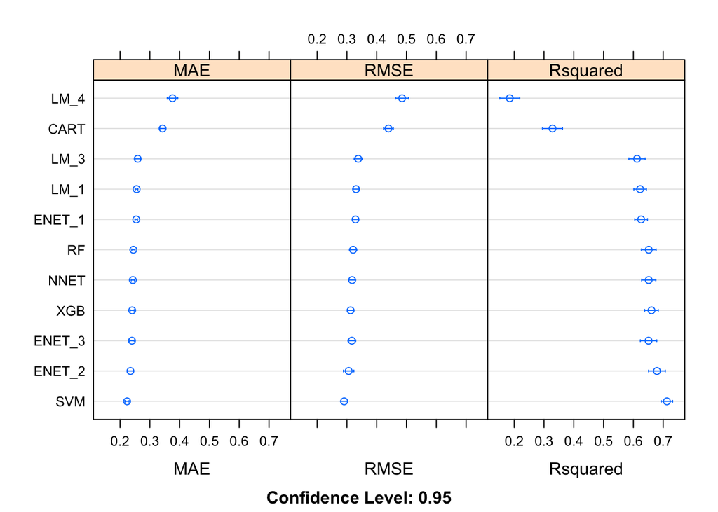

```r
dotplot(my_results)
```

According to the results of MAE, RMSE and Rsquared, I will choose SVM as the best model.